# Analyzing r/wallstreetbets Sentiment

Oliver Hammond, Jake Reiners, Marit McQuaig

12/6/2021

### Overview

[WallStreetBets](https://www.reddit.com/r/wallstreetbets/), a subreddit on the website “Reddit,” is a casual (and often vulgar) forum for users to discuss the stock market with other amateur investors. Despite this laid-back approach to investing, the overall sentiment of the subreddit does seem influenced by the stock market. This subreddit has had an impact on the stock market as well; the beginning of the GameStop short squeeze in January 2021 has been attributed to users of r/wallstreetbets. In our project we want to investigate the daily sentiment of the WallStreetBets subreddit based on the posted comments each day. We analyzed the sentiment of the subreddit from February 19th, 2019 until February 16th, 2021. After finding the daily sentiment of the subreddit we compared it to the performance of the S&P 500 ($SPY).

### Dataset

We used two datasets, both formatted similarly. They can be found at https://www.kaggle.com/mattpodolak/reddit-wallstreetbets-comments and https://www.kaggle.com/mattpodolak/rwallstreetbets-posts-and-comments. The first dataset contains 34 million rows with the first comment occurring on January 31st, 2012 and the most recent comment on February 16th, 2021. The last third of the original dataset was corrupted to the point that we couldn’t read it in, so we used the second dataset, which spans from December 2020 to February 2021 to partially fill in that gap. We focused on two variables for our analysis:

**Body:** Text of each reddit comment

**Created UTC:** Date-time of posting since the epoch of Linux-Bash in seconds

### Preprocessing and Parallelization

Due to size and sentiment analysis run time the data is preprocessed and analyzed in parallel before being aggregated. We split the first dataset into 34 files of 1 million lines and the second dataset into 10 files of 1 million lines. Due to unresolvable parsing issues with the original kaggle dataset, 11 chunks (~11 million comments) of the first dataset were unusable. Since bash has difficulty reading csvs containing natural language, we conducted the data splitting in Python.

After splitting, each of these files ran in an individual job on the CHTC. Since the dataset is not sorted by date in the original dataset, comments from the same day are spread across multiple files. Due to size and time restraints, we did not sort the dataset by date before splitting and instead handled this problem in the post processing portion of the pipeline.

### Computation

The R library sentimentr was utilized to find the average sentiment of comments each day. The jobs used the sentiment analysis library to score each comment from -1 to 1, ranging from strongly negative to strongly positive, and then return the average sentiment for each day.

Each job also outputs the number of comments for each day in the file process. As mentioned earlier, comments for a specific date can be spread over multiple files. A weighted average was used to combine values from different files. The final aggregated output is a single file with a row per date containing the average sentiment.

### Analysis

Once the computations completed, we graphed the daily average sentiment against the daily changes in the SPY stock. We focused on the daily change because we are more interested in understanding the relationship between reddit sentiment and the change of the stock rather than the absolute value. That said we also compared the cumulative sentiment to the daily closing values of the S&P to see if the community at r/wallstreetbets picked up on more general trends.

### Results

When comparing the average cumulative sentiment of the subreddit with the SPY closing value, there is a slight correlation (correlation coefficient of 0.514). Clearly, r/wallstreetbets users picked up on major peaks and drops in the market, but that was about it. It also appears that the sentiment on the “front page of the internet” takes a little bit longer to recover after a dip than the actual market does.

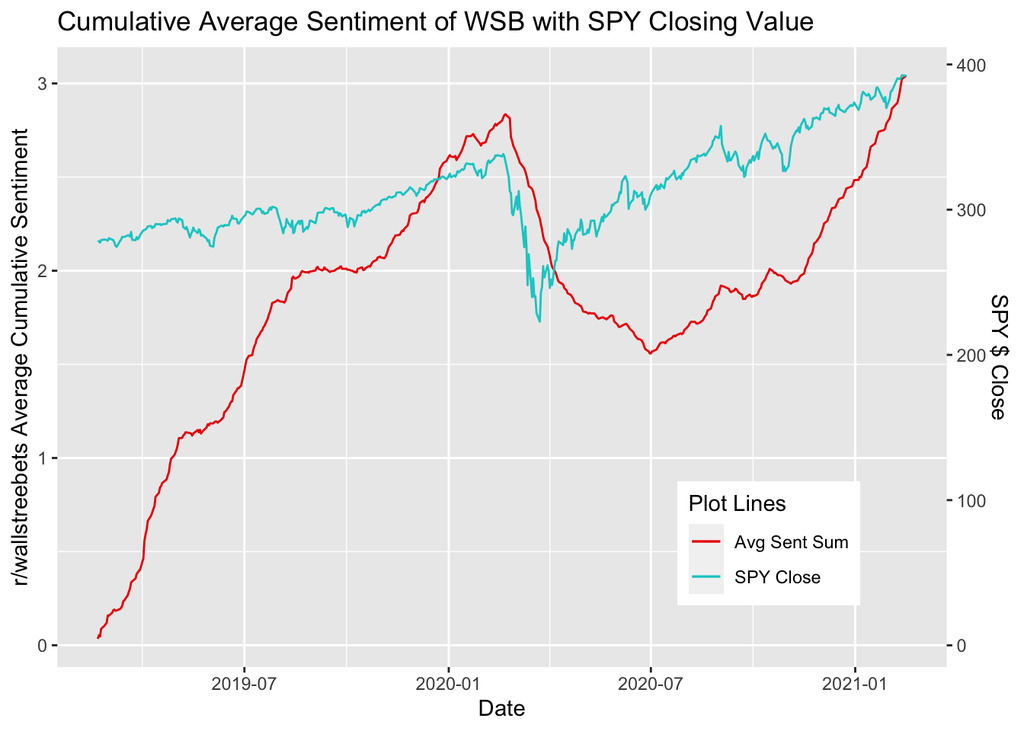

Due to the issues with the original dataset, we had some gaps over certain dates in our dataset. We were able to use data at four different time periods, each with its own graph below. Our results didn’t indicate a strong correlation between the r/wallstreetbets comments and the S&P daily differential. There are several reasons this could be the case:

- This is an open forum on the internet where anyone can say anything they want, whether they pay attention to and/or are knowledgable about the stock market.
- There’s plenty of sarcasm, emojis, and other slang used in comments that could’ve made sentiment analysis performed by a machine unreliable.

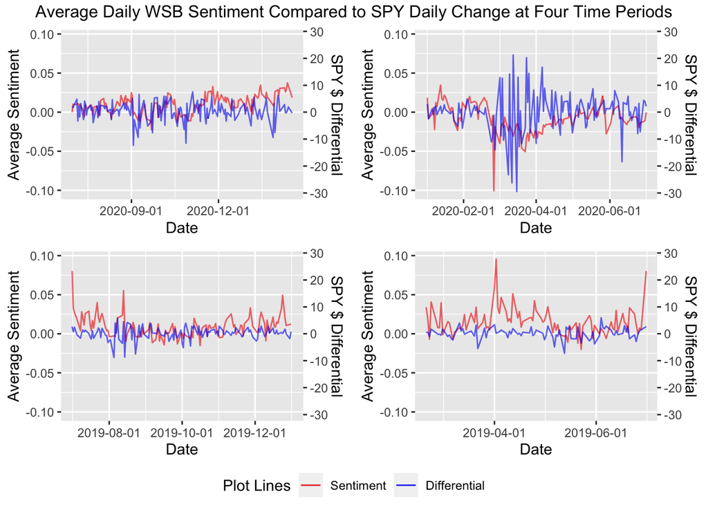

#### [GitHub Link](https://github.com/ohammond1/605FinalProject)